# intro_to_regression_lab

Data

```r
counties_2016_sample_bootcamp <- read.csv("~/Desktop/R Things/bootcamp/day_3/counties_2016_sample_bootcamp")
```

Librarys

```r
library(mosaic)
library(tidyverse)
library(sjPlot)
```

### Background

what varabuls are you going to use to mesure the competititive nes of the election, the education levle in the county? Note that there are sevral difrent options you might chouse from to reprepsent some of these varabusl. Why did you pick the ones that you did?

Make a ggplot with the varabuls you selcted

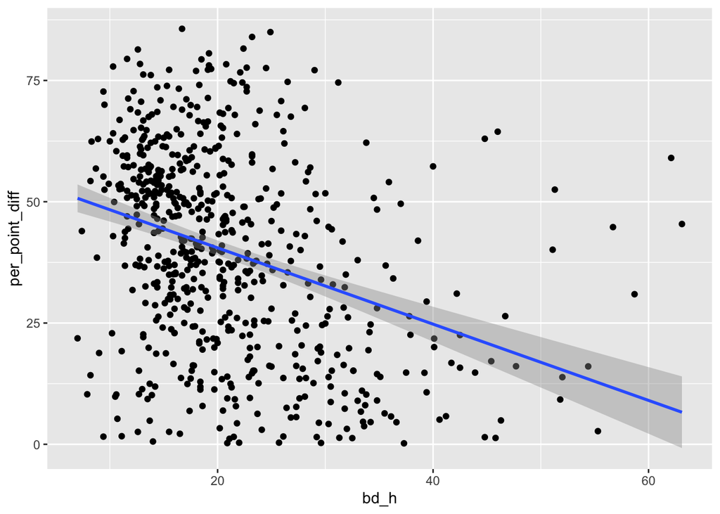

```r
ggplot(counties_2016_sample_bootcamp,
       aes(x=bd_h, y=per_point_diff)) +
       geom_point() +
       stat_smooth(method = "lm")
```

Build a regression model with these variabuls and look at the model output

```r
mod_1<-lm(per_point_diff~bd_h, counties_2016_sample_bootcamp)
summary(mod_1)
```

```
##
## Call:
## lm(formula = per_point_diff ~ bd_h, data = counties_2016_sample_bootcamp)
##
## Residuals:
##     Min      1Q  Median      3Q     Max
## -47.241 -14.173  -0.038  12.819  51.633
##
## Coefficients:
##             Estimate Std. Error t value Pr(>|t|)
## (Intercept) 56.21019    2.00119  28.088   <2e-16 ***
## bd_h        -0.78604    0.08755  -8.978   <2e-16 ***
## ---
## Signif. codes:  0 '***' 0.001 '**' 0.01 '*' 0.05 '.' 0.1 ' ' 1
##
## Residual standard error: 19.5 on 626 degrees of freedom
## Multiple R-squared:  0.1141, Adjusted R-squared:  0.1127
## F-statistic: 80.61 on 1 and 626 DF,  p-value: < 2.2e-16
```

Make a nice table like you might see in a paer of your model output.

```r
tab_model(mod_1)
```

|  | per point diff |  |  |
| --- | --- | --- | --- |
| Predictors | Estimates | CI | p |
| (Intercept) | 56.21 | 52.28 – 60.14 | **<0.001** |
| bd_h | -0.79 | -0.96 – -0.61 | **<0.001** |
| Observations | 628 |  |  |
| R<sup>2</sup> / R<sup>2</sup> adjusted | 0.114 / 0.113 |  |  |

What is the neater of the rlationship between the education fo the district and its competatitveenes?

Why might this be the case?

Now say that you hypothisesed that Metro countys where driving this realtionship and that you wouldn not se this same relationships in non metro countys. to test this hypothis you would build an interaction between the type of county and the education level of the county into your model.

Butild a ggpolt that takes this interaction into acount.

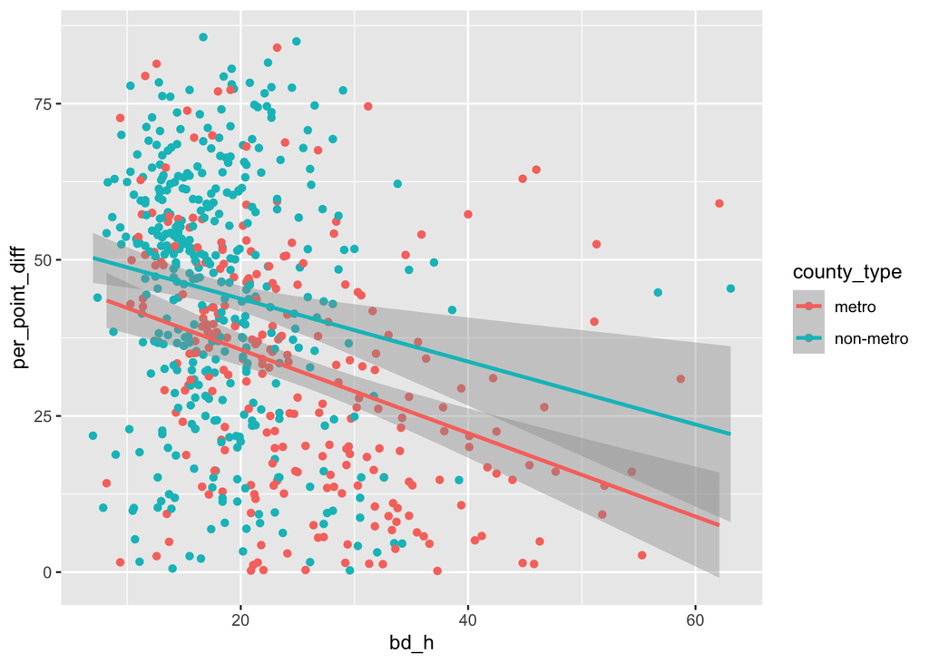

```r
ggplot(counties_2016_sample_bootcamp,
       aes(x=bd_h, y=per_point_diff, color=county_type)) +
       geom_point() +
       stat_smooth(method = "lm")
```

Build a regresion model that thakes this interaction into acount.

```r
mod_2<-lm(per_point_diff~bd_h*county_type, counties_2016_sample_bootcamp)
summary(mod_2)
```

```
##
## Call:
## lm(formula = per_point_diff ~ bd_h * county_type, data = counties_2016_sample_bootcamp)
##
## Residuals:
##     Min      1Q  Median      3Q     Max
## -46.579 -13.611   1.723  13.465  51.527
##
## Coefficients:
##                           Estimate Std. Error t value Pr(>|t|)
## (Intercept)                48.9819     3.2332  15.150  < 2e-16 ***
## bd_h                       -0.6679     0.1181  -5.655 2.37e-08 ***
## county_typenon-metro        4.8510     4.3846   1.106    0.269
## bd_h:county_typenon-metro   0.1648     0.1935   0.852    0.395
## ---
## Signif. codes:  0 '***' 0.001 '**' 0.01 '*' 0.05 '.' 0.1 ' ' 1
##
## Residual standard error: 19.16 on 624 degrees of freedom
## Multiple R-squared:  0.1476, Adjusted R-squared:  0.1435
## F-statistic: 36.02 on 3 and 624 DF,  p-value: < 2.2e-16
```

Given the regression out put and the interaction plot, would you argue that there is a meaniful interaction between the metro or non-metro status of a county?